# 因子分析から回帰分析

## 概要

1. データ読み込み
2. 前処理として次元圧縮を行う
3. 50の区市町を何らかの基準でクラスタに分けたい …クラスタリング
4. 人気度がどのような要因に基づくのかを分析したい…回帰分析

## １．データ読み込み

### ファイルを読み込んでデータフレームを作成する

```r
DF <- read.table( "TokyoSTAT_P25.csv",
                  sep = ",",
                  header = TRUE,
                  stringsAsFactors = FALSE,
                  fileEncoding="UTF-8")     #文字コードはUTF-8
DT::datatable(DF)
```

|  | 市町村 | 行政CD | 人気度 | 世帯あたり人数 | 年齢15未満比率 | 年齢65以上比率 | 転入者_対人口比 | 転出者_対人口比 | 昼間人口比_per | 高齢単身世帯比率 | 第1次産業従業者数比 | 第2次産業従業者数比 | 第3次産業従業者数比 | 可住地面積比率 | 耕地面積_対可住面積比 | 課税所得_就業者1人あたり_千円 | 小売業販売額_事業所あたり_百万円 | 小売業販売額_売場面積あたり_万円m2 | 国民健保一人あたり診療費_円 | ごみリサイクル率_pct | 千人あたり事業所数 | 千人あたり幼稚園数 | 千人あたり飲食店数 | 千人あたり大型小売店数 | 千人あたり病院数 | 千人あたり老人ホーム数 | 千人あたり交通事故発生件数 | 千人あたり刑法犯認知件数 |
| --- | --- | --- | --- | --- | --- | --- | --- | --- | --- | --- | --- | --- | --- | --- | --- | --- | --- | --- | --- | --- | --- | --- | --- | --- | --- | --- | --- | --- |
| 1 | 千代田区 | 13101 | 160 | 1.8433 | 0.1073 | 0.1916 | 0.1572 | 0.1046 | 1738.8 | 0.0966 | 0.0001 | 0.1054 | 0.8945 | 1 | 0.0101 | 11449.581 | 383.3745 | 233.971 | 211080 | 18.3 | 754.8764 | 0.2547 | 79.2953 | 1.9102 | 0.3184 | 0.0637 | 29.0141 | 95.1714 |
| 2 | 中央区 | 13102 | 125 | 1.8058 | 0.1054 | 0.1589 | 0.1236 | 0.0869 | 493.6 | 0.0809 | 0.0002 | 0.1195 | 0.8803 | 1 | 0.0101 | 6737.9314 | 610.7298 | 244.1373 | 211614 | 18.3 | 337.6778 | 0.1303 | 44.2727 | 0.8879 | 0.0326 | 0.057 | 9.8646 | 28.706 |
| 3 | 港区 | 13103 | 214 | 1.8629 | 0.1118 | 0.1698 | 0.1065 | 0.0878 | 432 | 0.0919 | 0.0001 | 0.1534 | 0.8465 | 1 | 0.0101 | 16954.8785 | 391.3318 | 377.0145 | 207795 | 18.3 | 207.9842 | 0.1462 | 27.7871 | 0.4972 | 0.0731 | 0.039 | 11.9631 | 27.8066 |
| 4 | 新宿区 | 13104 | 147 | 1.6697 | 0.0766 | 0.1865 | 0.0855 | 0.0798 | 229.9 | 0.1048 | 0.0001 | 0.1087 | 0.8912 | 1 | 0.0101 | 6040.9687 | 422.1306 | 213.1701 | 196377 | 18.3 | 107.7322 | 0.1042 | 17.6918 | 0.3432 | 0.049 | 0.0398 | 6.0342 | 33.1986 |
| 5 | 文京区 | 13105 | 151 | 1.849 | 0.0976 | 0.1853 | 0.0827 | 0.072 | 167.2 | 0.0979 | 0 | 0.1443 | 0.8557 | 1 | 0.0101 | 6630.5134 | 104.3095 | 163.6207 | 217984 | 18.3 | 77.241 | 0.1355 | 7.366 | 0.092 | 0.0532 | 0.0484 | 4.2783 | 11.7217 |
| 6 | 台東区 | 13106 | 67 | 1.8439 | 0.0856 | 0.2315 | 0.078 | 0.066 | 167.5 | 0.1168 | 0.0001 | 0.1606 | 0.8393 | 1 | 0.0101 | 4345.2555 | 207.4598 | 211.5546 | 210835 | 18.3 | 150.5389 | 0.1137 | 17.7459 | 0.1876 | 0.0455 | 0.0455 | 6.0593 | 32.2291 |
| 7 | 墨田区 | 13107 | 51 | 2.0498 | 0.1043 | 0.2131 | 0.0723 | 0.0582 | 112.8 | 0.1042 | 0 | 0.2348 | 0.7652 | 1 | 0.0101 | 3797.2741 | 138.2319 | 114.2827 | 224527 | 18.3 | 73.0354 | 0.0646 | 7.2898 | 0.1292 | 0.0565 | 0.0323 | 4.2083 | 16.2799 |
| 8 | 江東区 | 13108 | 71 | 2.1491 | 0.1206 | 0.1911 | 0.063 | 0.0527 | 119.1 | 0.096 | 0.0002 | 0.1714 | 0.8284 | 1 | 0.0101 | 4248.9747 | 200.1558 | 110.6404 | 235694 | 18.3 | 44.039 | 0.0716 | 4.6786 | 0.1411 | 0.0369 | 0.0347 | 3.854 | 14.5741 |
| 9 | 品川区 | 13109 | 123 | 1.8625 | 0.0985 | 0.1912 | 0.0735 | 0.0658 | 144.3 | 0.0989 | 0.0001 | 0.1643 | 0.8356 | 1 | 0.0101 | 5077.2037 | 245.0704 | 211.3705 | 236408 | 18.3 | 61.8228 | 0.0739 | 7.205 | 0.1697 | 0.0356 | 0.0411 | 3.3753 | 13.7338 |
| 10 | 目黒区 | 13110 | 163 | 1.944 | 0.0958 | 0.1923 | 0.0839 | 0.0793 | 109.3 | 0.0926 | 0.0007 | 0.124 | 0.8753 | 1 | 0.0101 | 7649.9095 | 150.4508 | 159.1183 | 210350 | 18.3 | 47.3559 | 0.0894 | 5.5901 | 0.1081 | 0.0335 | 0.0634 | 4.092 | 11.8623 |

[output cut: 40 more lines]

```r
str(DF) #Structure
```

```
## 'data.frame':    50 obs. of  28 variables:
##  $ 市町村                            : chr  "千代田区" "中央区" "港区" "新宿区" ...
##  $ 行政CD                            : int  13101 13102 13103 13104 13105 13106 13107 13108 13109 13110 ...
##  $ 人気度                            : int  160 125 214 147 151 67 51 71 123 163 ...
##  $ 世帯あたり人数                    : num  1.84 1.81 1.86 1.67 1.85 ...
##  $ 年齢15未満比率                    : num  0.1073 0.1054 0.1118 0.0766 0.0976 ...
##  $ 年齢65以上比率                    : num  0.192 0.159 0.17 0.186 0.185 ...
##  $ 転入者_対人口比                   : num  0.1572 0.1236 0.1065 0.0855 0.0827 ...
##  $ 転出者_対人口比                   : num  0.1046 0.0869 0.0878 0.0798 0.072 ...
##  $ 昼間人口比_per                    : num  1739 494 432 230 167 ...
##  $ 高齢単身世帯比率                  : num  0.0966 0.0809 0.0919 0.1048 0.0979 ...
##  $ 第1次産業従業者数比               : num  1e-04 2e-04 1e-04 1e-04 0e+00 1e-04 0e+00 2e-04 1e-04 7e-04 ...
##  $ 第2次産業従業者数比               : num  0.105 0.119 0.153 0.109 0.144 ...
##  $ 第3次産業従業者数比               : num  0.894 0.88 0.847 0.891 0.856 ...
##  $ 可住地面積比率                    : num  1 1 1 1 1 1 1 1 1 1 ...
##  $ 耕地面積_対可住面積比             : num  0.0101 0.0101 0.0101 0.0101 0.0101 0.0101 0.0101 0.0101 0.0101 0.0101 ...
##  $ 課税所得_就業者1人あたり_千円     : num  11450 6738 16955 6041 6631 ...
##  $ 小売業販売額_事業所あたり_百万円  : num  383 611 391 422 104 ...
##  $ 小売業販売額_売場面積あたり_万円m2: num  234 244 377 213 164 ...
##  $ 国民健保一人あたり診療費_円       : int  211080 211614 207795 196377 217984 210835 224527 235694 236408 210350 ...
##  $ ごみリサイクル率_pct              : num  18.3 18.3 18.3 18.3 18.3 18.3 18.3 18.3 18.3 18.3 ...
##  $ 千人あたり事業所数                : num  754.9 337.7 208 107.7 77.2 ...
##  $ 千人あたり幼稚園数                : num  0.255 0.13 0.146 0.104 0.136 ...
##  $ 千人あたり飲食店数                : num  79.3 44.27 27.79 17.69 7.37 ...
##  $ 千人あたり大型小売店数            : num  1.91 0.888 0.497 0.343 0.092 ...
##  $ 千人あたり病院数                  : num  0.3184 0.0326 0.0731 0.049 0.0532 ...
##  $ 千人あたり老人ホーム数            : num  0.0637 0.057 0.039 0.0398 0.0484 0.0455 0.0323 0.0347 0.0411 0.0634 ...
##  $ 千人あたり交通事故発生件数        : num  29.01 9.86 11.96 6.03 4.28 ...
##  $ 千人あたり刑法犯認知件数          : num  95.2 28.7 27.8 33.2 11.7 ...
```

```r
summary(DF[, -c(1:2)])
```

```
##      人気度       世帯あたり人数  年齢15未満比率   年齢65以上比率
##  Min.   : 11.00   Min.   :1.653   Min.   :0.0737   Min.   :0.1589
##  1st Qu.: 21.00   1st Qu.:1.945   1st Qu.:0.1046   1st Qu.:0.1893
##  Median : 39.50   Median :2.122   Median :0.1195   Median :0.2010
##  Mean   : 61.38   Mean   :2.138   Mean   :0.1154   Mean   :0.2023
##  3rd Qu.: 82.25   3rd Qu.:2.317   3rd Qu.:0.1285   3rd Qu.:0.2145
##  Max.   :214.00   Max.   :2.752   Max.   :0.1553   Max.   :0.2480
##  転入者_対人口比   転出者_対人口比   昼間人口比_per    高齢単身世帯比率
##  Min.   :0.03010   Min.   :0.03100   Min.   :  74.90   Min.   :0.06970
##  1st Qu.:0.04267   1st Qu.:0.04220   1st Qu.:  86.47   1st Qu.:0.08450
##  Median :0.05710   Median :0.05170   Median :  92.15   Median :0.09270
##  Mean   :0.06119   Mean   :0.05500   Mean   : 150.96   Mean   :0.09412
##  3rd Qu.:0.07208   3rd Qu.:0.06495   3rd Qu.: 110.20   3rd Qu.:0.10218
##  Max.   :0.15720   Max.   :0.10460   Max.   :1738.80   Max.   :0.13050
##  第1次産業従業者数比 第2次産業従業者数比 第3次産業従業者数比 可住地面積比率
##  Min.   :0.000000    Min.   :0.0650      Min.   :0.5932      Min.   :0.3687
##  1st Qu.:0.000200    1st Qu.:0.1106      1st Qu.:0.7783      1st Qu.:0.9864
##  Median :0.000600    Median :0.1624      Median :0.8375      Median :0.9996
##  Mean   :0.000798    Mean   :0.1741      Mean   :0.8251      Mean   :0.9492
##  3rd Qu.:0.001075    3rd Qu.:0.2213      3rd Qu.:0.8887      3rd Qu.:1.0000
##  Max.   :0.003500    Max.   :0.4054      Max.   :0.9349      Max.   :1.0000
##  耕地面積_対可住面積比 課税所得_就業者1人あたり_千円
##  Min.   :0.01010       Min.   : 2831
##  1st Qu.:0.01010       1st Qu.: 3519
##  Median :0.02520       Median : 3971
##  Mean   :0.05467       Mean   : 4744
##  3rd Qu.:0.08707       3rd Qu.: 4778
##  Max.   :0.20630       Max.   :16955
##  小売業販売額_事業所あたり_百万円 小売業販売額_売場面積あたり_万円m2
##  Min.   : 81.09                   Min.   : 68.95
##  1st Qu.:145.44                   1st Qu.: 91.87
##  Median :165.73                   Median :110.73
##  Mean   :198.68                   Mean   :129.05
##  3rd Qu.:211.69                   3rd Qu.:147.85
##  Max.   :610.73                   Max.   :377.01
##  国民健保一人あたり診療費_円 ごみリサイクル率_pct 千人あたり事業所数
##  Min.   :196377              Min.   :18.30        Min.   : 26.06
##  1st Qu.:210896              1st Qu.:18.30        1st Qu.: 31.05
##  Median :221345              Median :30.35        Median : 38.36
##  Mean   :220784              Mean   :28.73        Mean   : 68.46
##  3rd Qu.:228451              3rd Qu.:37.15        3rd Qu.: 49.89
##  Max.   :249198              Max.   :52.40        Max.   :754.88
##  千人あたり幼稚園数 千人あたり飲食店数 千人あたり大型小売店数 千人あたり病院数
##  Min.   :0.03610    Min.   : 2.263     Min.   :0.0540         Min.   :0.01660
##  1st Qu.:0.06635    1st Qu.: 3.163     1st Qu.:0.1074         1st Qu.:0.03335
##  Median :0.07405    Median : 4.237     Median :0.1217         Median :0.04535
##  Mean   :0.08286    Mean   : 7.875     Mean   :0.1987         Mean   :0.05560
##  3rd Qu.:0.08955    3rd Qu.: 6.285     3rd Qu.:0.1680         3rd Qu.:0.06582
##  Max.   :0.25470    Max.   :79.295     Max.   :1.9102         Max.   :0.31840
##  千人あたり老人ホーム数 千人あたり交通事故発生件数 千人あたり刑法犯認知件数
##  Min.   :0.02930        Min.   : 2.635             Min.   : 9.242
##  1st Qu.:0.04605        1st Qu.: 3.534             1st Qu.:12.200
##  Median :0.06005        Median : 3.915             Median :14.659
##  Mean   :0.06767        Mean   : 5.008             Mean   :17.899
##  3rd Qu.:0.07845        3rd Qu.: 4.631             3rd Qu.:16.933
##  Max.   :0.21020        Max.   :29.014             Max.   :95.171
```

## ２．因子分析による次元削減

### 並行分析で因子数を検討

- 最適な因子数、主成分分析の主成分数を見つけるため、平行分析を行う
- fa.parallel：平行分析（PA）の実施（視覚的に適切な因子数を判断）
- fm＝因子抽出法（minres最小残差法、pa主因子法、ml最尤法）
- ここでは最尤法を選択
- 1-2列目はIDなので除く
- 3列目は次元圧縮の対象ではないので除く

```r
result.prl <- fa.parallel(DF[, -(1:3)], fm="ml")
```

```
## In smc, smcs < 0 were set to .0
## In smc, smcs < 0 were set to .0
```

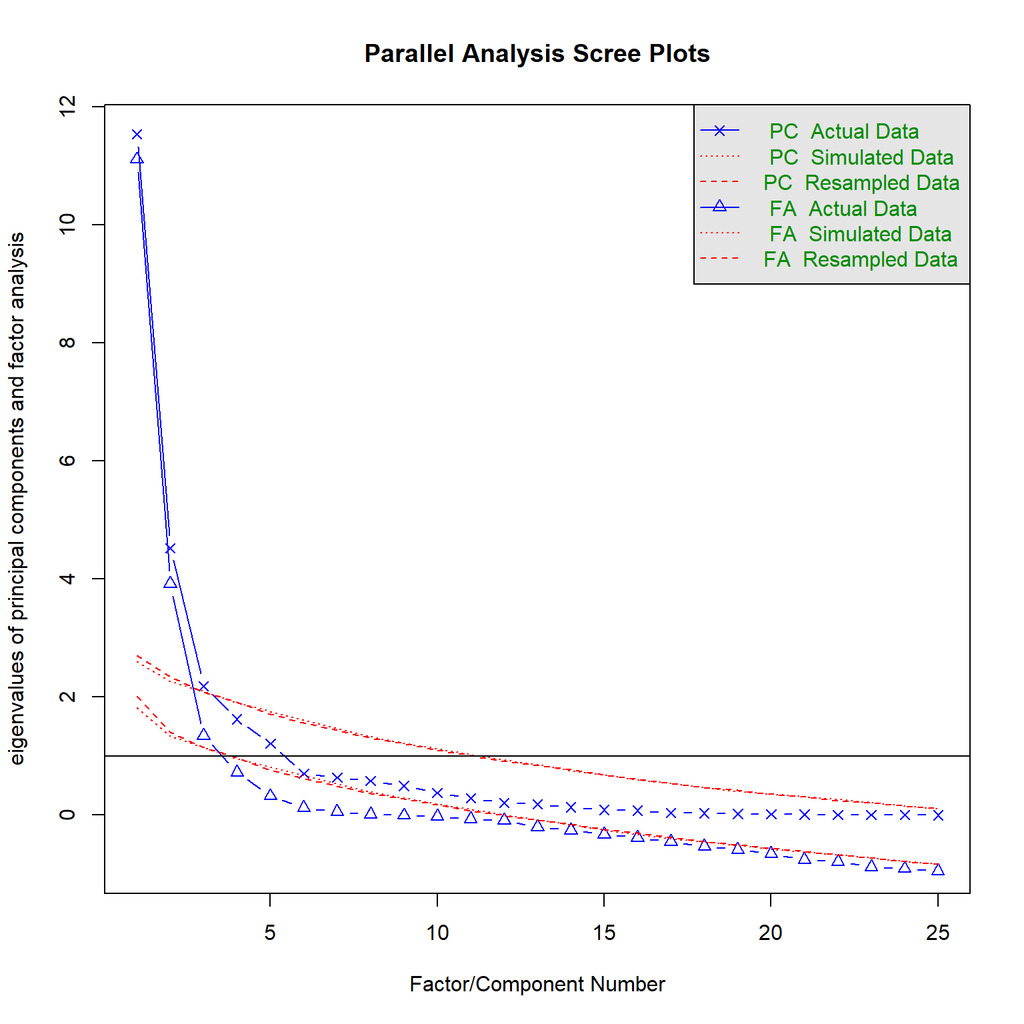

```
## Parallel analysis suggests that the number of factors =  3  and the number of components =  2
```

### FA（因子分析）の実行

- fa：因子分析の実行
- fm＝因子抽出法（minres最小残差法、pa主因子法、ml最尤法）
- ここでは最尤法を選択
- nfactors＝因子数（抽出したい軸の数）
- rotate＝回転法（直交回転:varimax等、斜交回転:promax等）
- scores＝因子得点算出法
- 1-2列目はIDなので除く
- 3列目は次元圧縮の対象ではないので除く

```r
resultFA <- fa(DF[, -(1:3)],
               nfactors=3,             #因子数を指定
               fm = "ml",              #pa 主因子法, ols 最小二乗法, ml 最尤法
               rotate = "varimax",     #varimax 直交、promax 斜交
               scores = "regression")  #regression 回帰法
```

```
## In smc, smcs < 0 were set to .0
## In smc, smcs < 0 were set to .0
```

### FA結果の表示

- digits＝小数点以下表示桁の指定
- sort=TRUEを指定（各項目ごとの因子負荷量がソートされる）
- MRi…：各項目ごとの因子負荷量（各変数がどれだけ因子に寄与しているか）
- h2：共通性–各変数の値の変動が因子でどれだけ説明できるかを表す
- u2＝1-h2：独自性（uniqueness）–取りこぼしの度合（救えなかった情報）

```r
print(resultFA, digits=2, sort=TRUE)
```

```
## Factor Analysis using method =  ml
## Call: fa(r = DF[, -(1:3)], nfactors = 3, rotate = "varimax", scores = "regression",
##     fm = "ml")
## Standardized loadings (pattern matrix) based upon correlation matrix
##                                    item   ML1   ML2   ML3   h2     u2 com
## 千人あたり事業所数                   18  0.97  0.16  0.14 1.00 0.0046 1.1
## 昼間人口比_per                        6  0.97  0.11  0.12 0.97 0.0310 1.1
## 千人あたり大型小売店数               21  0.95  0.12  0.20 0.97 0.0327 1.1
## 千人あたり飲食店数                   20  0.95  0.22  0.19 0.98 0.0171 1.2
## 千人あたり交通事故発生件数           24  0.95  0.00  0.14 0.92 0.0828 1.0
## 千人あたり刑法犯認知件数             25  0.91  0.23  0.05 0.88 0.1202 1.1
## 千人あたり幼稚園数                   19  0.80  0.24  0.14 0.71 0.2866 1.2
## 千人あたり病院数                     22  0.79 -0.01 -0.26 0.70 0.3041 1.2
## 転入者_対人口比                       4  0.65  0.62  0.41 0.98 0.0240 2.7
## 課税所得_就業者1人あたり_千円        13  0.50  0.43  0.43 0.62 0.3762 2.9
## 小売業販売額_事業所あたり_百万円     14  0.49  0.17  0.45 0.47 0.5291 2.2
## 世帯あたり人数                        1 -0.16 -0.92 -0.28 0.95 0.0504 1.3
## 年齢15未満比率                        2 -0.06 -0.91 -0.09 0.83 0.1683 1.0
## 高齢単身世帯比率                      7  0.03  0.74 -0.65 0.96 0.0376 2.0
## 転出者_対人口比                       5  0.48  0.71  0.49 0.97 0.0282 2.6
## 耕地面積_対可住面積比                12 -0.13 -0.64 -0.11 0.45 0.5545 1.1
## 千人あたり老人ホーム数               23  0.01 -0.63 -0.16 0.43 0.5712 1.1
## 可住地面積比率                       11  0.01  0.60  0.06 0.36 0.6363 1.0
## 小売業販売額_売場面積あたり_万円m2   15  0.44  0.58  0.34 0.65 0.3502 2.5
## 第3次産業従業者数比                  10  0.09  0.54  0.23 0.35 0.6498 1.4
## 第1次産業従業者数比                   8 -0.20 -0.54  0.08 0.34 0.6635 1.3
## 第2次産業従業者数比                   9 -0.09 -0.54 -0.23 0.35 0.6537 1.4
## ごみリサイクル率_pct                 17 -0.24 -0.53  0.11 0.36 0.6444 1.5
## 年齢65以上比率                        3 -0.10 -0.19 -0.85 0.77 0.2339 1.1
## 国民健保一人あたり診療費_円          16 -0.15 -0.34 -0.48 0.36 0.6382 2.0
##
##                        ML1  ML2  ML3
## SS loadings           8.22 6.34 2.75
## Proportion Var        0.33 0.25 0.11
## Cumulative Var        0.33 0.58 0.69
## Proportion Explained  0.47 0.37 0.16
## Cumulative Proportion 0.47 0.84 1.00
##
## Mean item complexity =  1.5
## Test of the hypothesis that 3 factors are sufficient.
##
## The degrees of freedom for the null model are  300  and the objective function was  62.46 with Chi Square of  2488.15
## The degrees of freedom for the model are 228  and the objective function was  29.15
##
## The root mean square of the residuals (RMSR) is  0.07
## The df corrected root mean square of the residuals is  0.08
##
## The harmonic number of observations is  50 with the empirical chi square  152.34  with prob <  1
## The total number of observations was  50  with Likelihood Chi Square =  1102.82  with prob <  1.2e-114
##
## Tucker Lewis Index of factoring reliability =  0.442
## RMSEA index =  0.276  and the 90 % confidence intervals are  0.263 0.296
## BIC =  210.88
## Fit based upon off diagonal values = 0.98
## Measures of factor score adequacy
##                                                    ML1  ML2  ML3
## Correlation of (regression) scores with factors   1.00 0.99 0.98
## Multiple R square of scores with factors          1.00 0.98 0.96
## Minimum correlation of possible factor scores     0.99 0.97 0.93
```

### FA結果を図で表示

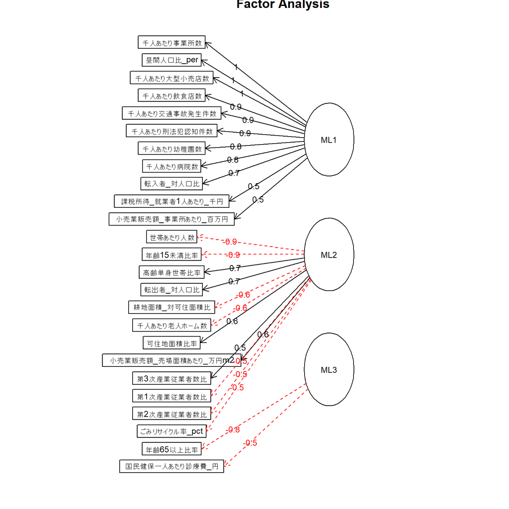

```r
fa.diagram(resultFA,
           rsize=0.8, e.size=0.1, #四角と円のサイズ
           marg=c(.5,5,.5,.5),    #余白の設定
           cex=1)
```

```r
#文字サイズ
```

### 因子負荷量をプロットする

- 因子負荷量（変数ごとの因子への寄与）の値をタテヨコにプロットする。
- どの変数がどの因子に寄与しているかを把握できる。
- 第1因子と第2因子

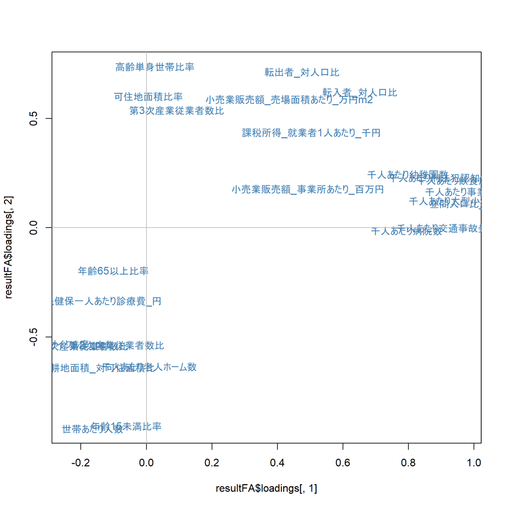

```r
#枠のみを作成する
#   type="n"で点を描かない
# 　因子負荷量は、resultFAの中のloadingsに格納されている
plot(resultFA$loadings[, 1],
     resultFA$loadings[, 2], type="n")
#枠内にテキストを表示する
#   テキストは因子負荷量のリストの行の名前を取得して使う
text(resultFA$loadings[, 1],
     resultFA$loadings[, 2],
     rownames(resultFA$loadings), col="steelblue")
#y=0の直線を引く
#   点(-1, 0)から点(1, 0)まで線を引けばよい
#   lines(X, Y)でXとYのベクトルを指定する（散布図と同じ）
lines(c(-1, 1), c(0, 0), col="grey")
#x=0の直線を引く
#   点(0, -1)から点(0, 1)まで線を引けばよい
lines(c(0, 0), c(-1, 1), col="grey")
```

- 第3因子と第2因子についても同様

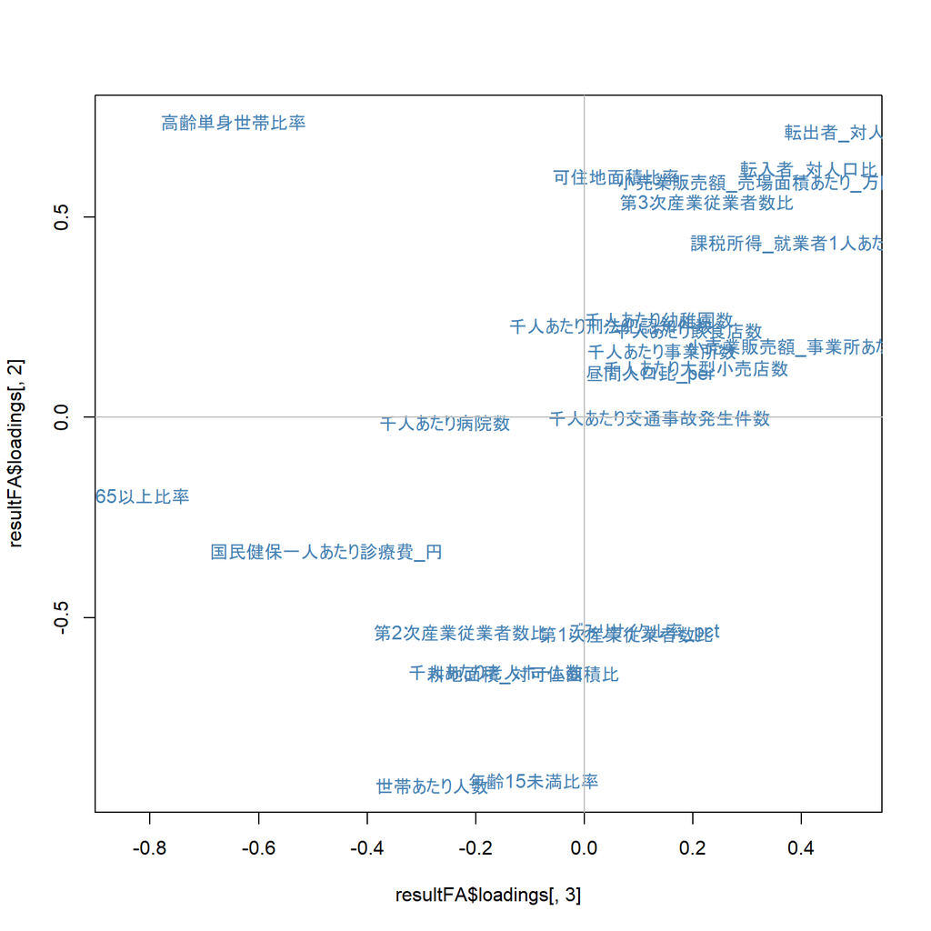

```r
plot(resultFA$loadings[, 3],
     resultFA$loadings[, 2], type="n")
text(resultFA$loadings[, 3],
     resultFA$loadings[, 2],
     rownames(resultFA$loadings), col="steelblue")
lines(c(-1, 1), c(0, 0), col="grey")
lines(c(0, 0), c(-1, 1), col="grey")
```

### 因子得点を確認

```r
#因子得点(ケースごとの得点)はresultFAの中のscoresに格納されている
head(resultFA$scores)
```

```
##             ML1         ML2        ML3
## [1,]  6.2895870 -0.02716594 -0.1498758
## [2,]  1.9784715  0.37974252  2.1079943
## [3,]  0.9587813  0.89614706  1.6124407
## [4,]  0.1089774  1.56147987  0.5499490
## [5,] -0.2597744  1.05513493  0.6792591
## [6,]  0.5595381  1.39528629 -1.1532270
```

```r
#因子得点をデータフレームに変換
DFfa <- as.data.frame(resultFA$scores)
#行の名前を自治体名に変換
rownames(DFfa) <- DF$市町村

#意味を考えて因子に名前を付ける
names(DFfa) = c("ビジネス度","都会生活度","非高齢化度")
DT::datatable(DFfa)
```

|  | ビジネス度 | 都会生活度 | 非高齢化度 |
| --- | --- | --- | --- |
| 千代田区 | 6.28958698465904 | -0.0271659427280769 | -0.149875808427468 |
| 中央区 | 1.97847147743164 | 0.379742523740831 | 2.10799433451601 |
| 港区 | 0.958781314800803 | 0.896147061527138 | 1.61244065744904 |
| 新宿区 | 0.108977410869892 | 1.56147986811328 | 0.54994901202093 |
| 文京区 | -0.259774402121079 | 1.05513492891164 | 0.679259058027191 |
| 台東区 | 0.559538074016659 | 1.39528629377808 | -1.15322697907668 |
| 墨田区 | -0.0618049652546435 | 0.673865795702721 | -0.456607039987658 |
| 江東区 | -0.240677373382037 | 0.130575551157363 | -0.0117897216876858 |
| 品川区 | -0.288474658966197 | 0.89841044102136 | 0.373958909658513 |
| 目黒区 | -0.544399636423725 | 0.996856084789809 | 1.27387563342848 |

[output cut: 40 more lines]

```r
#因子得点について要約情報を表示
summary(DFfa)
```

```
##    ビジネス度         都会生活度         非高齢化度
##  Min.   :-0.61191   Min.   :-2.13525   Min.   :-2.2253
##  1st Qu.:-0.32143   1st Qu.:-0.67470   1st Qu.:-0.5168
##  Median :-0.18727   Median :-0.01814   Median : 0.1106
##  Mean   : 0.00000   Mean   : 0.00000   Mean   : 0.0000
##  3rd Qu.:-0.03774   3rd Qu.: 0.69898   3rd Qu.: 0.6469
##  Max.   : 6.28959   Max.   : 1.65261   Max.   : 2.1080
```

```r
#標準偏差
apply(DFfa, 2, sd)
```

```
## ビジネス度 都会生活度 非高齢化度
##  0.9975664  0.9917397  0.9812517
```

## ３．因子得点をもとにクラスタリング

### kMeans×因子得点でクラスタリング

```r
kmFA <- kmeans(DFfa, 4, iter.max=50)

#色ラベルの配列を作るためにクラスタ番号の配列をコピー
color.kmFA <- kmFA$cluster
head(color.kmFA)
```

```
## 千代田区   中央区     港区   新宿区   文京区   台東区
##        3        4        4        4        4        1
```

```r
#クラスタ番号を色名に変換する
#levels＝factor（カテゴリ変数）のラベルの指定
#クラスタの数に注意
color.kmFA <- as.factor(color.kmFA)
levels(color.kmFA) <- c("blue", "red", "green", "orange")
head(color.kmFA)
```

```
## 千代田区   中央区     港区   新宿区   文京区   台東区
##    green   orange   orange   orange   orange     blue
## Levels: blue red green orange
```

```r
#factorの実体は整数型なので文字列に変換（ラベルの値が実体となる）
color.kmFA <- as.character(color.kmFA)
head(color.kmFA)
```

```
## [1] "green"  "orange" "orange" "orange" "orange" "blue"
```

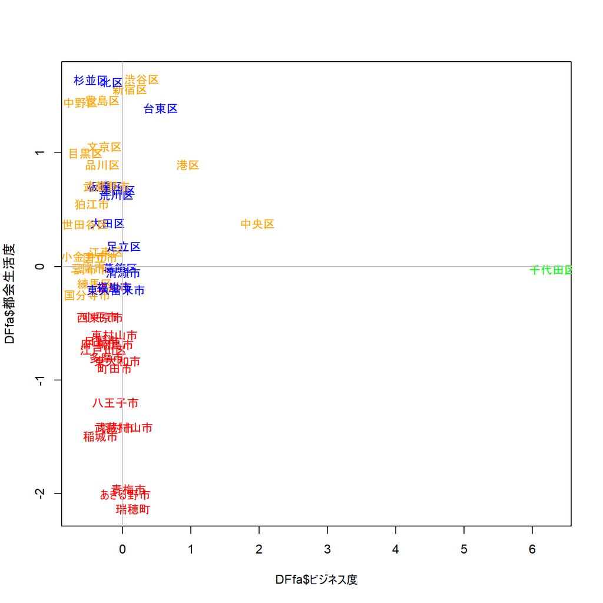

```r
#因子得点(サンプルごとの点数)の値を色分けしてプロットする
#ラベル(市町村名＝DFfaの行の名前)を rownames(DFfa) で表示
#クラスタの色名color.kmFAで色分けをして表示
plot(DFfa$ビジネス度,
     DFfa$都会生活度, type="n")
text(DFfa$ビジネス度,
     DFfa$都会生活度, rownames(DFfa), col=color.kmFA)
lines(c(-10, 10), c(0, 0), col="grey")
lines(c(0, 0), c(-10, 10), col="grey")
```

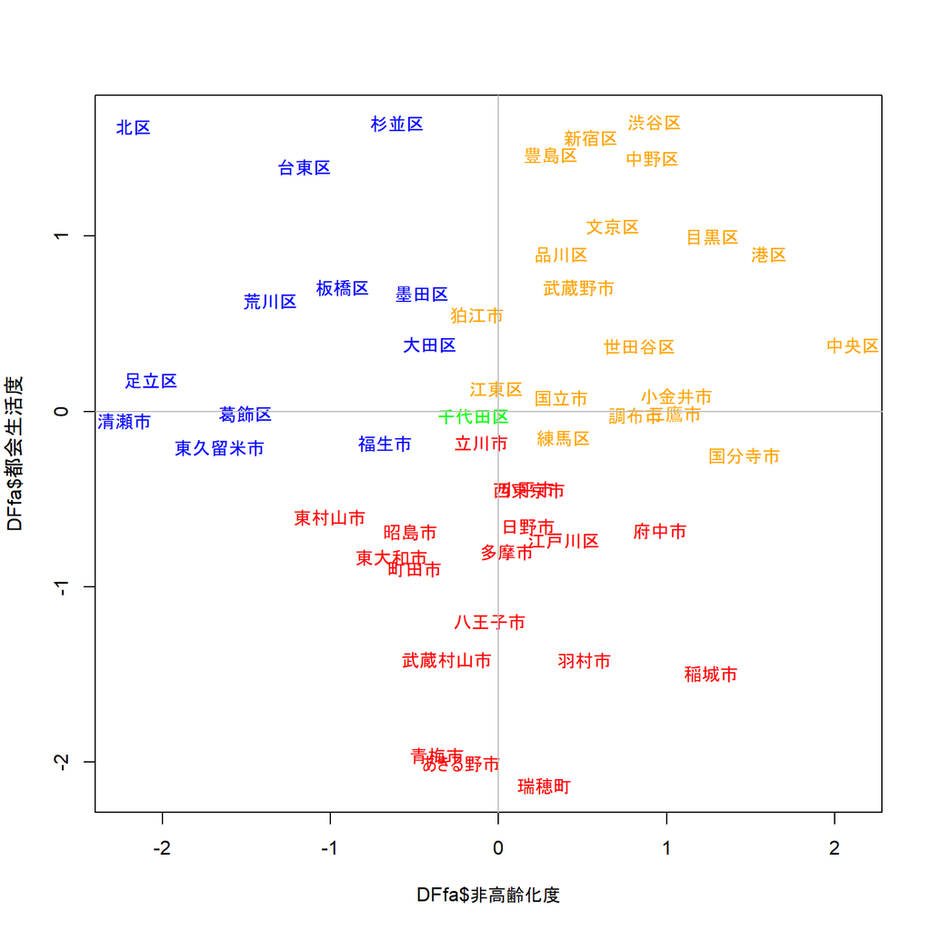

```r
plot(DFfa$非高齢化度,
     DFfa$都会生活度, type="n")
text(DFfa$非高齢化度,
     DFfa$都会生活度, rownames(DFfa), col=color.kmFA)
lines(c(-10, 10), c(0, 0), col="grey")
lines(c(0, 0), c(-10, 10), col="grey")
```

### 比較用：因子分析の有無によるkMeansの変化

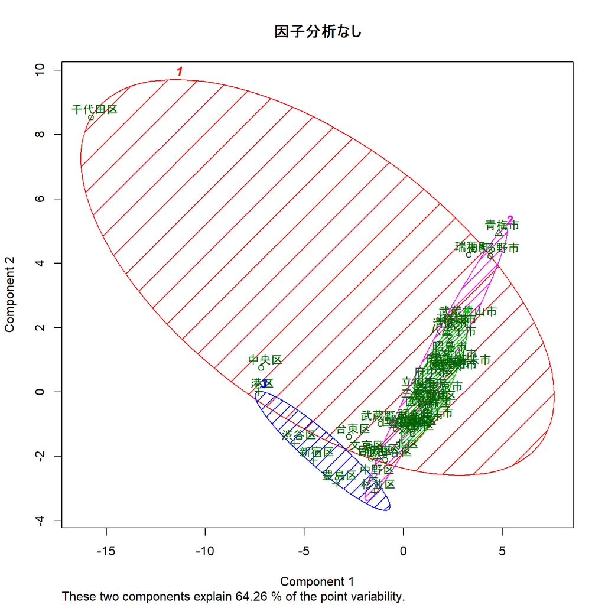

```r
DF_kmeans <- DF[, -(1:3)] %>% data.frame()
rownames(DF_kmeans) <- DF[,1]

kmFA2 <- kmeans(DF_kmeans, 4, iter.max=50)
require(cluster)
clusplot(DF_kmeans,kmFA2$cluster,color=TRUE,shade = TRUE,labels=2,lines=0,main = "因子分析なし",cex = 1)
```

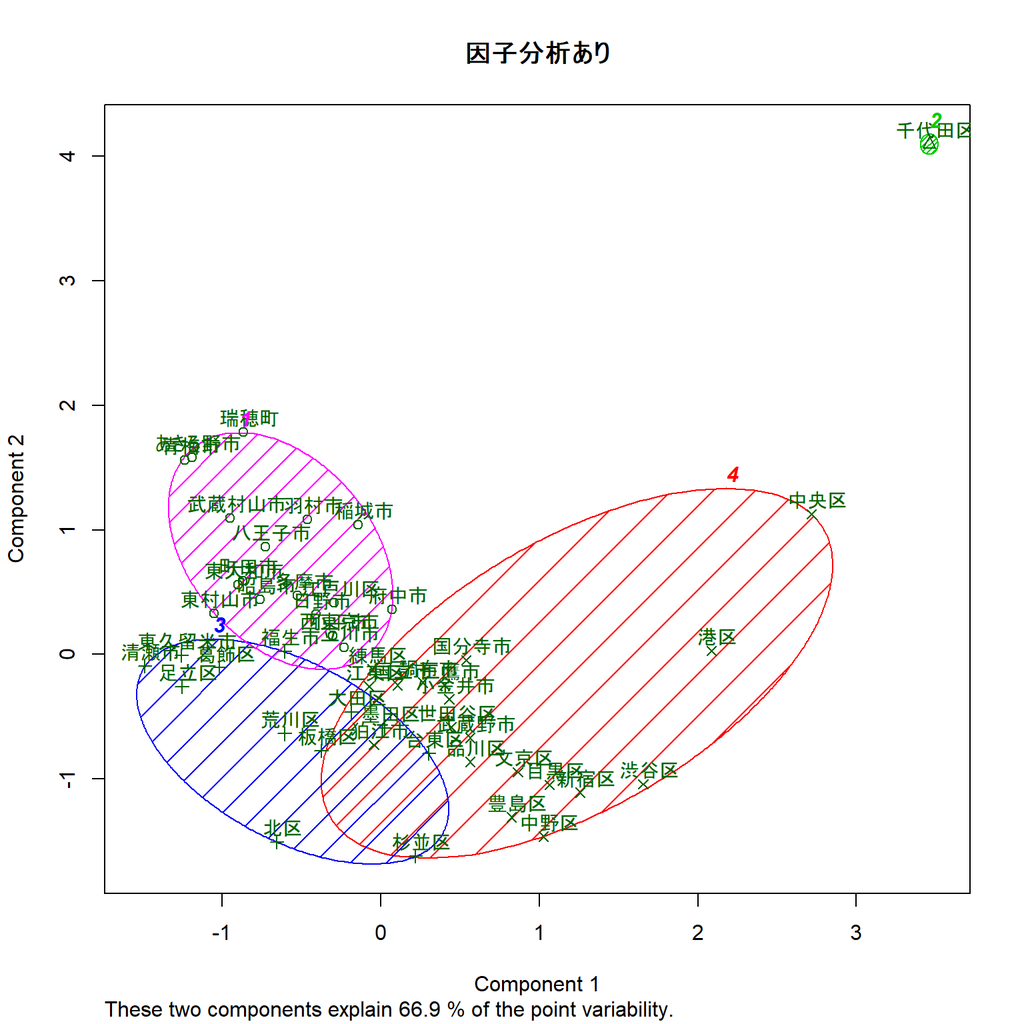

```r
kmFA3 <- kmeans(DFfa, 4, iter.max=50)
clusplot(DFfa,kmFA3$cluster,color=TRUE,shade = TRUE,labels=2,lines=0,main = "因子分析あり",cex = 1)
```